# Regresión logística con R - Hombres y Mujeres

Primero leemos los datos:

```r
data <- read.csv('HombresMujeres.csv', header = TRUE)
data
```

| Nombre | Género | Edad | Peso | salario | Riesgo | X | clase |
| --- | --- | --- | --- | --- | --- | --- | --- |
| María | F | 20 | 69 | 1000000 | 0,015037594 | no | 0 |
| Juana | F | 34 | 69 | 1100000 | 0,1210526316 | no | 0 |
| Camila | F | 57 | 52 | 1200000 | 0,2453720508 | si | 0 |
| Claudia | F | 44 | 51 | 1300000 | 0,1463091691 | no | 0 |
| Lorena | F | 43 | 53 | 1400000 | 0,1443826959 | no | 0 |
| María | F | 20 | 54 | 1500000 | 0,0129776496 | no | 0 |
| Jhoana | F | 40 | 65 | 1600000 | 0,1587830335 | no | 0 |
| Jimena | F | 46 | 97 | 1700000 | 0,2468866467 | si | 0 |
| Monica | F | 22 | 59 | 1800000 | 0,0267119411 | no | 0 |
| Claudia | F | 37 | 50 | 1900000 | 0,1141552511 | no | 0 |

[output cut: 19 more lines]

Una representación gráfica de los datos, puede obtenerse mediante:

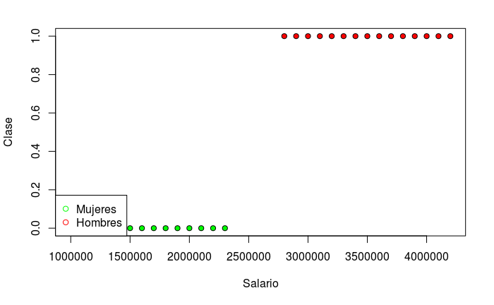

```r
colores <- NULL
colores[data$clase==0] <- 'green' #Mujeres
colores[data$clase==1] <- 'red' #Hombres
plot(data$salario, data$clase, pch = 21, bg = colores, xlab = 'Salario', ylab = 'Clase')
legend('bottomleft', c('Mujeres', 'Hombres'), pch = 21, col = c('green', 'red'))
```

Hemos usado los argumentos pch y bg para mejorar la apariencia del gráfico. También hemos usado el comando legend para incluir una leyenda explicativa.

Parece razonable, a la vista de los datos, pensar que el salario puede influir en la probabilidad de que una persona sea hombre o mujer. En esta práctica, vamos a ajustar un modelo de regresión logística para estudiar la posible relación. Para ajustar el modelo se usa el comando glm (para modelos lineales generalizados) indicando que la respuesta es binomial mediante el argumento family:

```r
reg <- glm(clase ~ salario, data = data, family=binomial)
```

```
glm.fit: algorithm did not convergeglm.fit: fitted probabilities numerically 0 or 1 occurred
```

```r
summary(reg)
```

```
Call:
glm(formula = clase ~ salario, family = binomial, data = data)

Deviance Residuals:
       Min          1Q      Median          3Q         Max
-2.653e-05  -2.110e-08   2.110e-08   2.110e-08   2.683e-05

Coefficients:
              Estimate Std. Error z value Pr(>|z|)
(Intercept) -2.219e+02  2.332e+05  -0.001    0.999
salario      8.703e-05  9.093e-02   0.001    0.999

(Dispersion parameter for binomial family taken to be 1)

    Null deviance: 4.0168e+01  on 28  degrees of freedom
Residual deviance: 1.4235e-09  on 27  degrees of freedom
AIC: 4

Number of Fisher Scoring iterations: 25
```

En el modelo de regresión logística la raíz de las desviaciones representa el papel de los residuos:

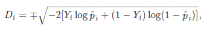

Para representar gráficamente la función logística estimada, calculamos las probabilidades estimadas de ser hombre o mujer (usando el comando predict) para un vector adecuado de nuevos salarios (entre 1 millon y 4.2 millones):

```r
datos <- data.frame(salario = seq(1000000, 4200000, 50000))
probabilidades <- predict(reg, datos, type = 'response')  # por defecto calcularía log p_i/(1-p_i), para calcular p_i usamos el argumento type
plot(data$salario, data$clase, pch = 21, bg = colores, xlab = 'Salario', ylab = 'Clase')
legend('bottomleft', c('Mujeres', 'Hombres'), pch = 21, col = c('green', 'red'))
```

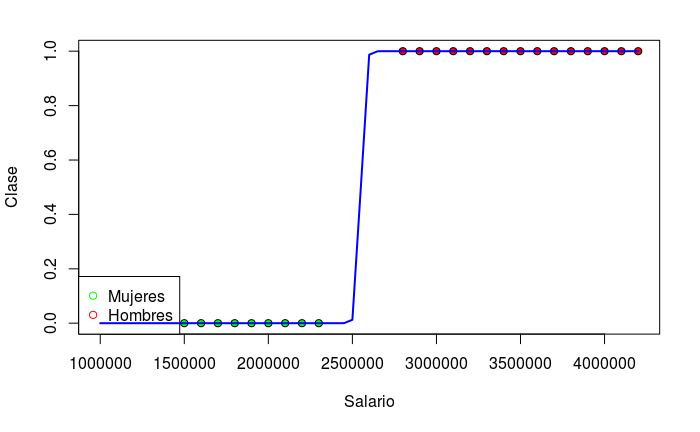

```r
lines(datos$salario, probabilidades, col = 'blue', lwd = 2)
```